# Modelado de Riesgo Agregado y Simulación Monte Carlo

Joey Trejo Boyso

2026-02-15

## Introducción

Este documento presenta la implementación analítica y computacional de diversos modelos de riesgo operativo. Para todos los casos analizados, el riesgo agregado de la compañía se define mediante el modelo colectivo:

$$S=\sum_{i=1}^N Y_i$$
Donde $N$ representa la frecuencia de los eventos de riesgo y $Y_i$ representa la severidad de cada evento individual. A lo largo del documento, se exploran métodos de cálculo exacto (Recursión de Panjer), aproximaciones (Normal con corrección por continuidad) y validaciones empíricas mediante simulaciones de Monte Carlo en R.

## Caso 1: Cálculo de Momentos en Modelos Colectivos

**Planteamiento:** Sea $S$ la variable aleatoria que mide el riesgo de una compañía bajo un modelo colectivo, donde las funciones generadoras de momentos de la severidad ($Y_i$) y de la frecuencia ($N$) están dadas por:

$$M_Y(t)= 0.7+0.3e^{(t)} \hspace{1cm} \& \hspace{1cm}
M_N(t)=\exp\left[ 5\left(e^{t}-1\right) \right]$$

### 1.1 Cálculo de la Esperanza $\mathbb{E}[S]$

Primero, analizamos si las funciones generadoras de momentos tienen alguna distribución conocida. Vemos que $N$ sigue una distribución Poisson de parámetro 5, pues en general se tiene el siguiente resultado:
$$X \sim \text{Poisson}(\lambda) \iff M_X(t) = \exp(\lambda(e^t - 1))$$
Por lo que podemos concluir que $N \sim \text{Poisson}(5)$.

Del mismo modo, para la variable de la severidad tenemos el siguiente resultado general:
$$X \sim \text{Bernoulli}(p) \iff M_X(t) = 1 - p + pe^t$$
De donde identificamos que $p=0.3$. De este modo:
$$Y \sim \text{Bernoulli}(0.3)$$

Aplicando la propiedad de la esperanza para el modelo colectivo:
$$\mathbb E[S]=\mathbb E[N]\mathbb E[Y]$$
Sabemos que la esperanza de una Poisson es su parámetro y la de una Bernoulli es $p$:
$$\mathbb E[N] = 5 \hspace{1cm} \text{y} \hspace{1cm} \mathbb E[Y] = 0.3$$
Por lo tanto:
$$\mathbb E[S] = 5 \times 0.3 = 1.5$$

### 1.2 Cálculo de $\mathbb{E}[e^S]$

Identificamos que esto es la definición de la función generadora de momentos de $S$ evaluada en $t=1$. En general se tiene:
$$M_S(t) := \mathbb{E}[e^{t \cdot S}] =M_{N}\left(\ln
\left(M_{Y}(t)\right)\right)$$
Aplicado a nuestro caso:
$$M_S(1) = \mathbb{E}[e^S] =M_{N}\left(\ln \left(M_{Y}(1)\right)\right)$$
Sustituyendo las funciones generadoras de momentos por las respectivas de cada distribución:
$$M_S(1) = \exp\left[5\left(e^{\ln[M_Y(1)]} - 1\right)\right]$$
Desarrollando esta expresión:
$$M_S(1)=\exp[5(M_Y(1) - 1)] = \exp[5( (0.7 + 0.3e) - 1 )] = \exp[5(
0.3e - 0.3 )]$$
Evaluando numéricamente obtenemos:
$$\mathbb{E}[e^S] = M_S(1) \approx 13.1632$$

## Caso 2: Aproximación Normal con Corrección por Continuidad

**Planteamiento:** A partir del caso anterior, buscamos obtener un valor $z$ tal que la probabilidad acumulada $F_S(4)$ se aproxime mediante la distribución normal estándar $\Phi(z)$.

Notamos que tanto la frecuencia como la severidad son discretas. Para aplicar la aproximación normal de manera robusta, aplicamos una corrección por continuidad expandiendo el intervalo.
$$\mathbb{P}[n\leq S\leq m]\approx \mathbb{P}\left[n-\frac{1}{2}\leq
S\leq m+\frac{1}{2}\right]$$
En nuestro caso:
$$F_S(4) \approx \mathbb{P}\left[S \le 4 + \frac{1}{2}\right] =
\mathbb{P}\left[S \le 4.5\right]$$
Procedemos a estandarizar la variable:
$$\mathbb{P}\left[ \frac{S - \mathbb E[S]}{\sqrt{\text{Var}(S)}} \le
\frac{4.5 - \mathbb E[S]}{\sqrt{\text{Var}(S)}} \right]$$
La varianza se obtiene mediante el siguiente teorema:
$$Var(S)=Var(N)\mathbb{E}^2[Y]+Var(Y)\mathbb{E}[N]$$
Sustituyendo los parámetros ya conocidos ($N \sim \text{Poi}(5)$, $Y \sim \text{Ber}(0.3)$):
$$Var(N) = 5 = \mathbb{E}[N]$$
$$\mathbb{E}^2[Y] = (0.3)^2 = 0.09$$
$$Var(Y)=p(1−p)=0.3(0.7)=0.21$$
Se sigue que:
$$Var(S)= 5(0.09) + 0.21(5) = 1.5$$
Por lo tanto:
$$\mathbb{P}\left[ Z \le \frac{4.5 - 1.5}{\sqrt{1.5}} \right] =
\Phi\left(\frac{3}{\sqrt{1.5}}\right) = \Phi(2.44949)$$
Concluimos que el valor requerido es $z = 2.44949$.

## Caso 3: Suma de Modelos de Poisson Compuesto

**Planteamiento:** Sea $S = S_1 + S_2$, donde $S_j$ es el riesgo de una compañía que sigue el siguiente modelo compuesto asumiendo independencia:
$$S_j\sim
\text{PoiComp}\left(\lambda_j=5j,F_{Y_j}(t)=\left(1-e^{-2jt}\right)\mathbb{I}_{(t\ge0)}^{(t)}\right)$$

Sabemos que si $S_1$ y $S_2$ tienen distribución Poisson Compuesta y son independientes, su suma sigue una distribución Poisson Compuesta con parámetro $\lambda = \lambda_1 + \lambda_2$ y función de distribución de severidad $F(x) = \sum \frac{\lambda_j}{\lambda}F_j(x)$.

Desarrollando los componentes:
$$S_1\sim \text{PoiComp}\left(\lambda_1=5,
F_{Y_1}(t)=\left(1-e^{-2t}\right)\mathbb{I}_{(t\ge0)}^{(t)}\right)$$
$$S_2\sim \text{PoiComp}\left(\lambda_2=10,
F_{Y_2}(t)=\left(1-e^{-4t}\right)\mathbb{I}_{(t\ge0)}^{(t)}\right)$$

### 3.1 Esperanza $\mathbb{E}[S]$

Por linealidad y propiedades del modelo compuesto:
$$\mathbb{E}[S] = \lambda_{1} \mathbb{E}[Y_{1}] +\lambda_{2}
\mathbb{E}[Y_{2}]$$
Reconocemos que las severidades tienen forma de distribución Exponencial ($X \sim \text{Exp}(\theta) \iff F_X(x) = 1 - e^{-\theta x}$): * $Y_1 \sim \text{Exp}(\theta_1 = 2) \implies \mathbb{E}[Y_1] = 1/2 = 0.5$ * $Y_2 \sim \text{Exp}(\theta_2 = 4) \implies \mathbb{E}[Y_2] = 1/4 = 0.25$

Sustituyendo:
$$\mathbb{E}[S] = 5(0.5) + 10(0.25) = 5$$

### 3.2 Varianza $Var(S)$

Bajo el supuesto de independencia, la covarianza es cero:
$$\text{Var}[S] = \lambda_1 \mathbb{E}[Y_1^2] + \lambda_2
\mathbb{E}[Y_2^2]$$
Calculamos los segundos momentos ($\mathbb{E}[Y^2] = \text{Var}(Y) + (\mathbb{E}[Y])^2$): * Para $Y_1$: $\mathbb{E}[Y_1^2] = (1/4) + (1/2)^2 = 1/2$ * Para $Y_2$: $\mathbb{E}[Y_2^2] = (1/16) + (1/4)^2 = 1/8$

Finalmente:
$$\text{Var}[S] = 5(1/2) + 10(1/8) = 3.75$$

## Caso 4: Resolución Exacta (Panjer) vs. Simulación Muestral (Monte Carlo)

**Planteamiento:** Sea $S\sim\text{PoiComp}\left(\lambda=3,F_{Y}\right)$ donde $Y$ tiene soporte discreto: $\mathbb{P}[Y=1] = 2/3$ y $\mathbb{P}[Y=2] = 1/3$.

### 4.1 Enfoque Teórico (Fórmula de Panjer)

La frecuencia distribuye Poisson, familia $(a,b,0)$ con $a = 0$ y $b = \lambda = 3$. Evaluamos recursivamente:

**Para $S=0$:**
$$g_0 = P(N=0) = e^{-3} \approx 0.049787$$

**Para $S=1$:**
$$g_1 = \left(\frac{3 \cdot 1}{1}\right) P(Y=1) g_{0} = 3
\left(\frac{2}{3}\right) e^{-3} = 2e^{-3} \approx 0.099574$$

**Para $S=2$:**
$$g_2 = \left[\frac{3}{2} P(Y=1) g_{1}\right] + \left[3 P(Y=2)
g_0\right] = 3e^{-3} \approx 0.149361$$

### 4.2 Implementación Computacional en R

Validamos nuestro marco teórico programando el algoritmo de Panjer y comparándolo contra una simulación de Monte Carlo de $1,000,000$ de iteraciones utilizando la librería `actuar`.

```r
# 1. Función Teórica de Panjer
Panjer <- function(r,a,b,p0,f,todo=F){
  g <- 0:r
  names(g) <- 0:r
  names(f) <- 1:(length(f))

  for(s in 0:r){
    if(s==0){
      g["0"] = p0
    } else {
      aux = 0
      for(j in 1:(min(s,length(f)))){
        aux = aux + (a+b*j/s)*f[as.character(j)]*g[as.character(s-j)]
      }
      g[as.character(s)] = aux
    }
  }
  if(todo) return(g) else return(g[as.character(r)])
}

# Parámetros del modelo
lambda <- 3
p0 <- exp(-lambda)
f <- c(2/3, 1/3)
names(f) <- 1:2

# Cálculo Teórico
probas_teo <- Panjer(r = 2, a = 0, b = lambda, p0 = p0, f = f, todo = TRUE)
print("Probabilidades Teóricas (Panjer):")
```

```
## [1] "Probabilidades Teóricas (Panjer):"
```

```r
print(probas_teo)
```

```
##          0          1          2
## 0.04978707 0.09957414 0.14936121
```

```r
# 2. Simulación Muestral (Monte Carlo)
set.seed(123)
n_sim <- 1000000

rY <- function(n) {
  sample(x = 1:2, size = n, replace = TRUE, prob = c(2/3, 1/3))
}

S_sim <- actuar::rcompound(n = n_sim,
                           model.freq = rpois(lambda = lambda),
                           model.sev = rY())

prob_muestrales <- prop.table(table(S_sim))[1:3]
print("Probabilidades Simuladas (Monte Carlo):")
```

```
## [1] "Probabilidades Simuladas (Monte Carlo):"
```

```r
print(prob_muestrales)
```

```
## S_sim
##        0        1        2
## 0.049942 0.099998 0.149501
```

### 4.3 Visualización de Resultados

Conforme a la Ley de los Grandes Números, las probabilidades empíricas convergen a las probabilidades teóricas generadas por el modelo recursivo. A continuación, se ilustra la precisión del modelo:

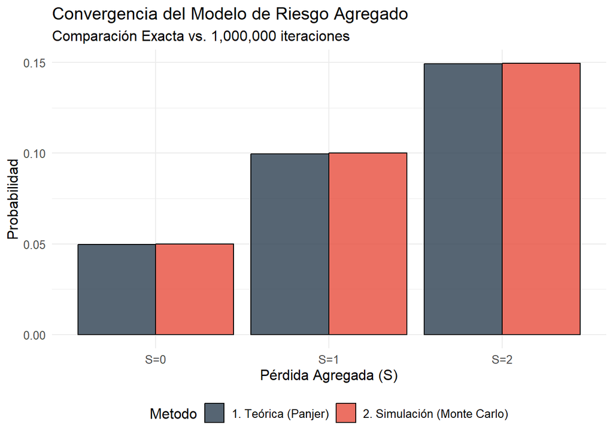

**Conclusión:** La convergencia es evidente. Esto nos permite interpretar con alto grado de certidumbre que es más probable que la pérdida total de la compañía sea de 2 unidades monetarias (~14.93%) a que sea de 1 unidad monetaria (~9.95%).